# Estatísticas Brasileiras

Criando Mais Mapas no R

Marcus Nunes

# 1 Pacotes Necessários

Execute os comandos presentes no arquivo `setup.R`, presente na pasta `scripts`, para instalar os pacotes que serão necessários durante o minicurso. O tempo de execução do comando vai variar dependendo da instalação do `R` em seu computador e da sua conexão à internet. O script vai localizar quais pacotes já estão instalados em sua máquina e irá baixar apenas aqueles que estiverem faltando.

# 2 R Markdown

Este é um documento R Markdown. Markdown é uma linguagem de *markup* para formatar textos para formatos como HTML, PDF e Word, dentre outros. Para mais detalhes sobre o formato, visite o link http://rmarkdown.rstudio.com.

Ao clicar no botão **Knit** acima ou utilizar o atalho **Ctrl+Shift+K**, será gerado um documento que juntará texto regular, código do `R` e os respectivos *outputs* destes códigos, unindo tudo em um mesmo documento.

## 2.1 Instruções Gerais

A criação de mapas no `R` pode ser um pouco lenta. Por isso, na linha 17 deste arquivo está uma opção identificada como `cache = TRUE`. Com isso, apenas trechos de códigos novos ou alterados serão executados a cada compilação do documento. Caso haja algum problema com a atualização dos resultados no arquivo html gerado, apague as pastas `02_estatisticas_brasileiras_cache` e `02_estatisticas_brasileiras_files` para que um novo arquivo seja compilado completamente a partir do zero.

# 3 País Inteiro

## 3.1 Mapas com Cidades

Como o pacote `giscoR` não apresenta dados detalhados o suficiente para todos os países do mundo, pois é focado na União Europeia, precisamos procurar uma alternativa para plotar dados do Brasil. Vamos usar o pacote `geobr` para isso.

```r
library(tidyverse)
theme_set(theme_void())
library(geobr)
```

A função `read_municipality` importa os dados dos mapas em nível municipal. Ou seja, com ela obtemos o mapa do Brasil com os limites entre cada cidade:

```r
cidades <- read_municipality(year = 2020, showProgress = FALSE)
```

```
## Using year 2020
```

Vamos conferir o conteúdo do objeto `cidades`:

```r
head(cidades)
```

```
## Simple feature collection with 6 features and 7 fields
## Geometry type: MULTIPOLYGON
## Dimension:     XY
## Bounding box:  xmin: -63.61801 ymin: -13.6937 xmax: -60.33317 ymax: -9.66916
## Geodetic CRS:  SIRGAS 2000
##   code_muni             name_muni code_state abbrev_state name_state
## 1   1100015 Alta Floresta D'oeste         11           RO   Rondônia
## 2   1100023             Ariquemes         11           RO   Rondônia
## 3   1100031                Cabixi         11           RO   Rondônia
## 4   1100049                Cacoal         11           RO   Rondônia
## 5   1100056            Cerejeiras         11           RO   Rondônia
## 6   1100064     Colorado Do Oeste         11           RO   Rondônia
##   code_region name_region                           geom
## 1           1       Norte MULTIPOLYGON (((-62.19465 -...
## 2           1       Norte MULTIPOLYGON (((-62.53648 -...
## 3           1       Norte MULTIPOLYGON (((-60.37119 -...
## 4           1       Norte MULTIPOLYGON (((-61.0008 -1...
## 5           1       Norte MULTIPOLYGON (((-61.49976 -...
## 6           1       Norte MULTIPOLYGON (((-60.50475 -...
```

São diversas informações:

- `code_muni`: código do município no IBGE
- `name_muni`: nome do município
- `code_state`: código da UF do município no IBGE
- `abbrev_state`: sigla da UF
- `name_state`: nome da UF
- `code_region`: código da região do país
- `name_region`: nome da região do país
- `geom`: mapa para cada municipio

A lógica para plotar o mapa do Brasil é a mesma que utilizamos para plotar o mapa múndi:

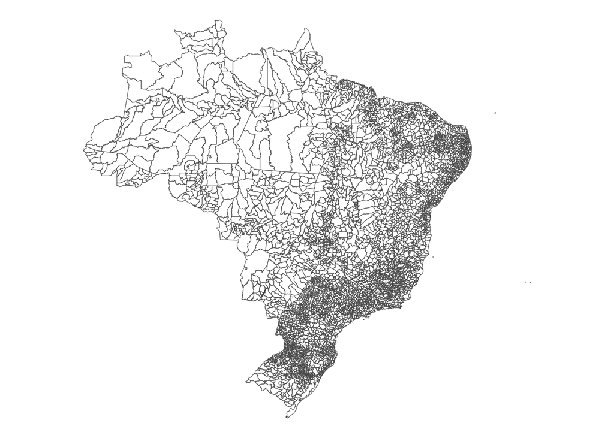

```r
ggplot(cidades) +
  geom_sf(fill = "white")
```

Mas se quisermos podemos plotar estatísticas em cima desde mapa. Em particular, vamos ler o conteúdo do arquivo `brasil.csv`:

```r
brasil <- read_csv(file = "dados/brasil.csv")
```

Estas são as suas primeiras linhas:

```r
head(brasil)
```

```
## # A tibble: 6 × 6
##   codigo_ibge municipio      uf                area populacao densidade
##         <dbl> <chr>          <chr>            <dbl>     <dbl>     <dbl>
## 1     3550308 São Paulo      São Paulo        1521.  11451245     7528.
## 2     3304557 Rio de Janeiro Rio de Janeiro   1200.   6211423     5175.
## 3     5300108 Brasília       Distrito Federal 5761.   2817068      489.
## 4     2304400 Fortaleza      Ceará             312.   2428678     7775.
## 5     2927408 Salvador       Bahia             693.   2418005     3487.
## 6     3106200 Belo Horizonte Minas Gerais      331.   2315560     6988.
```

Cada coluna apresenta uma informação diferente:

- `codigo_ibge`: código do município no IBGE
- `municipio`: nome do município
- `uf`: nome da UF
- `area`: área do município (km^2)
- `populacao`: quantidade de habitantes do município
- `densidade`: densidade populacional do município (habitantes/km^2)

Tome por exemplo os conjuntos de dados abaixo. Ambos possuem as mesmas pessoas, mas com informações diferentes sobre elas.

```r
telefones <- data.frame(nome = c("João", "Maria", "Pedro", "Roberta"),
                        telefone = c("84 99999-1000", "84 99999-2000", "84 99999-3000", "84 99999-4000"))

emails <- data.frame(nome = c("Maria", "Roberta", "João", "Pedro"),
                     email = c("m@ufrn.br", "roberta@gmail.com", "joao@ufrn.br", "pedro@hotmail.com"))

telefones
```

```
##      nome      telefone
## 1    João 84 99999-1000
## 2   Maria 84 99999-2000
## 3   Pedro 84 99999-3000
## 4 Roberta 84 99999-4000
```

```r
emails
```

```
##      nome             email
## 1   Maria         m@ufrn.br
## 2 Roberta roberta@gmail.com
## 3    João      joao@ufrn.br
## 4   Pedro pedro@hotmail.com
```

Note que `nome` é uma chave comum a ambos conjuntos de dados. Embora a ordem dos nomes não seja a mesma, a função `left_join` consegue relacionar ambos os conjuntos de dados e identificar quais informações devem ser atribuídas a cada pessoa:

```r
telefones |>
  left_join(emails, by = "nome")
```

```
##      nome      telefone             email
## 1    João 84 99999-1000      joao@ufrn.br
## 2   Maria 84 99999-2000         m@ufrn.br
## 3   Pedro 84 99999-3000 pedro@hotmail.com
## 4 Roberta 84 99999-4000 roberta@gmail.com
```

Iremos utilizar esta mesma lógica para unir os conjuntos `cidades` e `brasil`, para colocarmos as informações de ambos bancos de dados em um mesmo objeto. Neste caso, iremos sobrescrever o conteúdo de `cidades`. Como chave, utilizaremos o código do IBGE, para evitar problemas com acentuação (Mossoró vs Mossoro) ou grafia (Assu vs Açu) dos nomes dos municípios.

O resultado é o seguinte:

```r
cidades <-
  cidades |>
  rename(codigo_ibge = code_muni) |>
  left_join(brasil, by = "codigo_ibge")

head(cidades)
```

```
## Simple feature collection with 6 features and 12 fields
## Geometry type: MULTIPOLYGON
## Dimension:     XY
## Bounding box:  xmin: -63.61801 ymin: -13.6937 xmax: -60.33317 ymax: -9.66916
## Geodetic CRS:  SIRGAS 2000
##   codigo_ibge             name_muni code_state abbrev_state name_state
## 1     1100015 Alta Floresta D'oeste         11           RO   Rondônia
## 2     1100023             Ariquemes         11           RO   Rondônia
## 3     1100031                Cabixi         11           RO   Rondônia
## 4     1100049                Cacoal         11           RO   Rondônia
## 5     1100056            Cerejeiras         11           RO   Rondônia
## 6     1100064     Colorado Do Oeste         11           RO   Rondônia
##   code_region name_region             municipio       uf     area populacao
## 1           1       Norte Alta Floresta d'Oeste Rondônia 7067.025     22516
## 2           1       Norte             Ariquemes Rondônia 4426.571     96833
## 3           1       Norte                Cabixi Rondônia 1314.352      5067
## 4           1       Norte                Cacoal Rondônia 3792.892     86416
## 5           1       Norte            Cerejeiras Rondônia 2783.300     16088
## 6           1       Norte     Colorado do Oeste Rondônia 1451.060     15213
##   densidade                           geom
## 1  3.186065 MULTIPOLYGON (((-62.19465 -...
## 2 21.875397 MULTIPOLYGON (((-62.53648 -...
## 3  3.855132 MULTIPOLYGON (((-60.37119 -...
## 4 22.783670 MULTIPOLYGON (((-61.0008 -1...
## 5  5.780189 MULTIPOLYGON (((-61.49976 -...
## 6 10.484060 MULTIPOLYGON (((-60.50475 -...
```

Agora podemos criar um mapa colorindo as cidades de acordo com a sua densidade populacional:

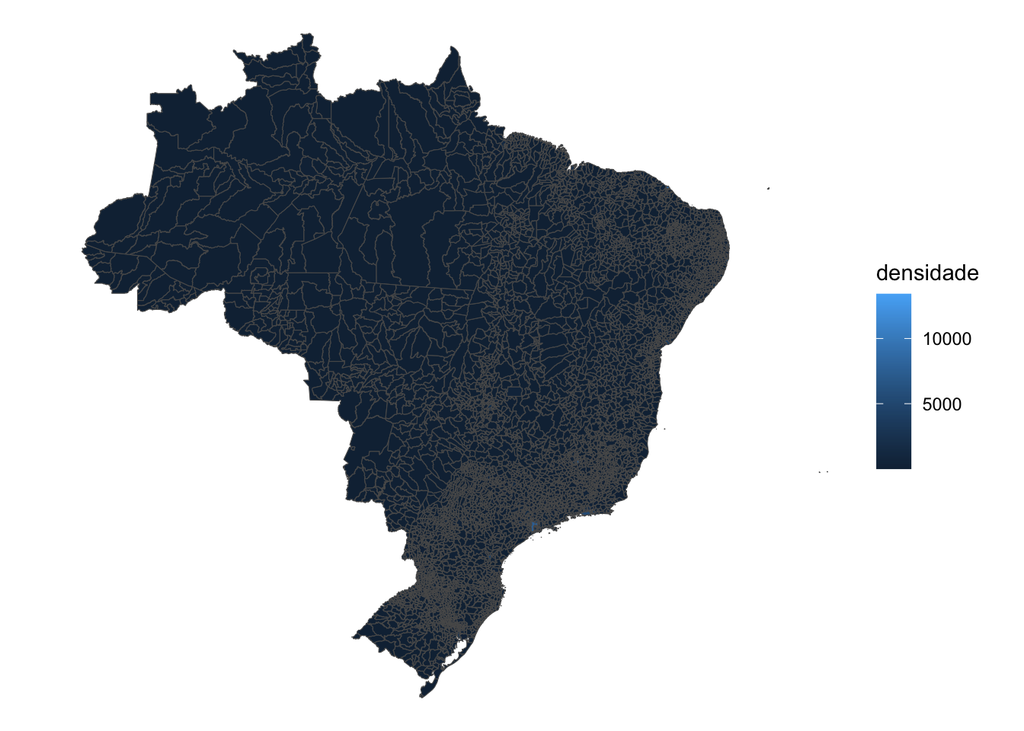

```r
ggplot() +
  geom_sf(data = cidades, aes(fill = densidade))
```

Remover a cor dos limites municipais melhora um pouco a visualização:

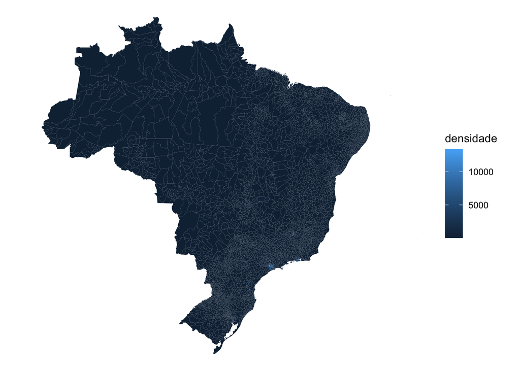

```r
ggplot() +
  geom_sf(data = cidades, aes(fill = densidade), colour = NA)
```

Mas parece que nossa escala de cores não está funcionando bem. Há alguns pontos mais claros no mapa, como São Pualo, Rio de Janeiro e Belo Horizonte, mas não é poséivel distinguir bem as outras cidades.

O histograma da densidade populacional nos ajuda compreender isso:

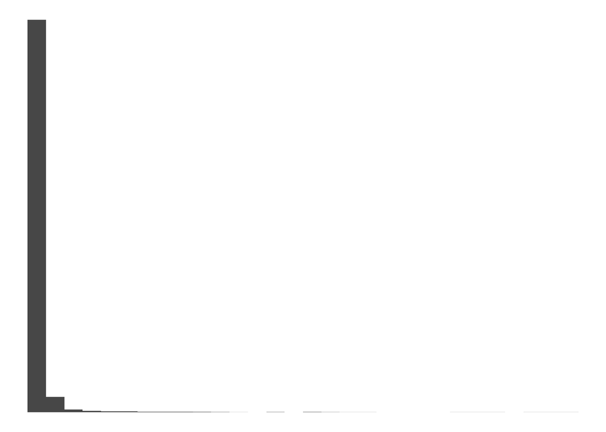

```r
ggplot(cidades, aes(x = densidade)) +
  geom_histogram()
```

Uma forma de reduzir a desiguldade que vemos é aplicando uma transformação logarítmica, que além de reduzir a amplitude dos dados, os deixam simétricos:

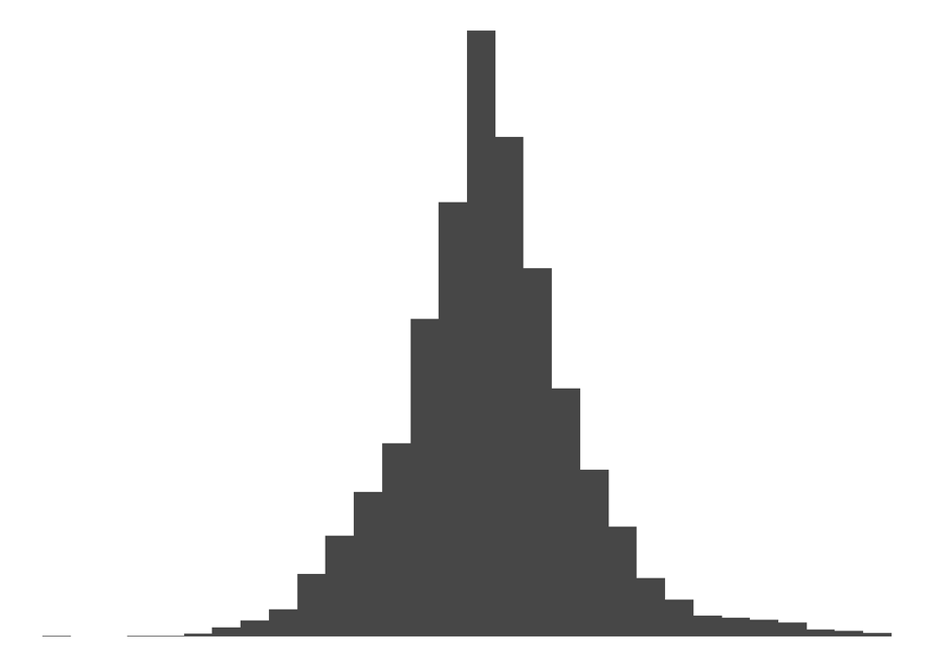

```r
ggplot(cidades, aes(x = densidade)) +
  geom_histogram() +
  scale_x_log10()
```

É trivial aplicar esta transformação no mapa:

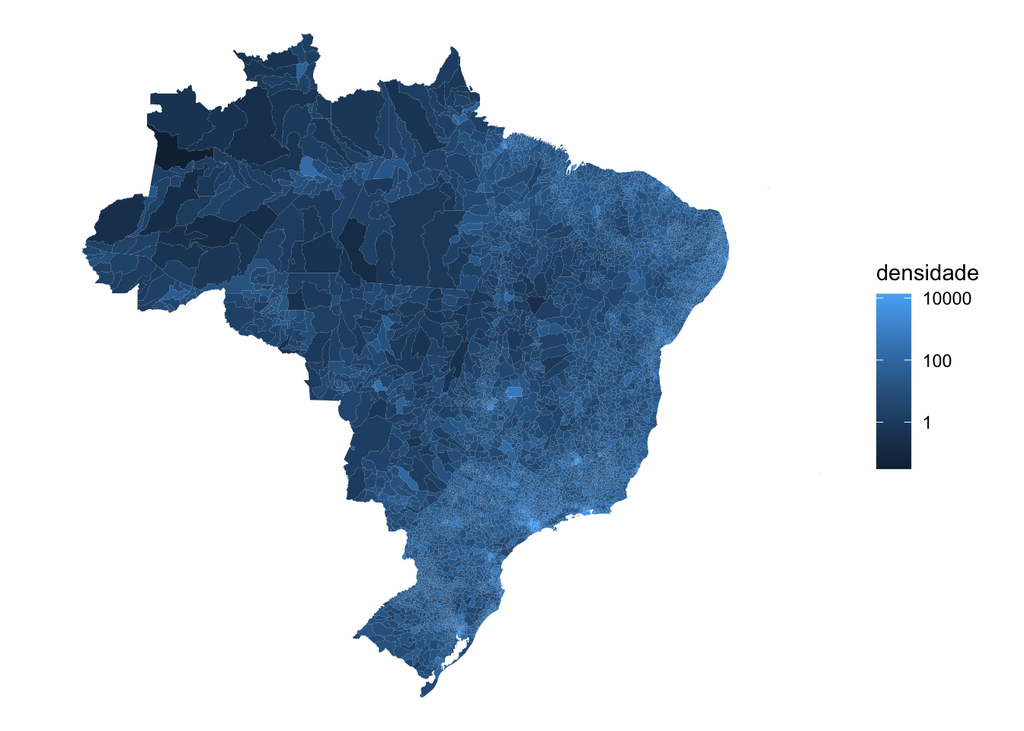

```r
ggplot() +
  geom_sf(data = cidades, aes(fill = densidade), colour = NA) +
  scale_fill_gradient(trans = "log10")
```

Agora sim está mais fácil perceber a maior densidade populacional no litoral do Brasil, enquanto o interior é menos densamente populado.

## 3.2 Mapas com Unidades Federativas

A função `read_state` funciona de maneira análoga à função `read_municipality`, exceto que só lê os mapas com divisões estaduais:

```r
uf <- read_state(year = 2020, showProgress = FALSE)
```

```
## Using year 2020
```

Como só possuímos os dados de densidade populacional para os municípios, precisamos agrupar estes dados por UF para termos a densidade populacional de cada Unidade Federativa do país.

```r
densidade_uf <-
  brasil |>
  group_by(uf) |>
  summarise(populacao_uf = sum(populacao),
            area_uf = sum(area)) |>
  mutate(densidade_uf = populacao_uf/area_uf)
```

Agora juntamos os mapas com os dados, como fizemos antes:

```r
names(uf)
```

```
## [1] "code_state"   "abbrev_state" "name_state"   "code_region"  "name_region"
## [6] "geom"
```

```r
names(densidade_uf)
```

```
## [1] "uf"           "populacao_uf" "area_uf"      "densidade_uf"
```

```r
uf <-
  uf |>
  rename(uf = name_state) |>
  left_join(densidade_uf, by = "uf")
```

E aí é só plotar o resultado:

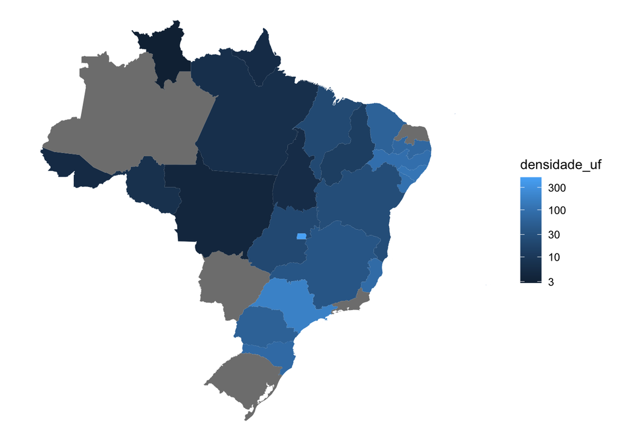

```r
ggplot() +
  geom_sf(data = uf, aes(fill = densidade_uf), colour = NA) +
  scale_fill_gradient(trans = "log10")
```

Note que algumas UFs não possuem dados plotados a seu respeito. Isto provavelmente se deve a diferentes grafias dos nomes dos estados nos objetos `uf` e `densidade_uf`:

```r
data.frame(sort(uf$uf), sort(densidade_uf$uf))
```

```
##            sort.uf.uf. sort.densidade_uf.uf.
## 1                 Acre                  Acre
## 2              Alagoas               Alagoas
## 3                Amapá                 Amapá
## 4             Amazônas              Amazonas
## 5                Bahia                 Bahia
## 6                Ceará                 Ceará
## 7     Distrito Federal      Distrito Federal
## 8       Espírito Santo        Espírito Santo
## 9                Goiás                 Goiás
## 10            Maranhão              Maranhão
## 11         Mato Grosso           Mato Grosso
## 12  Mato Grosso Do Sul    Mato Grosso do Sul
## 13        Minas Gerais          Minas Gerais
## 14                Pará                  Pará
## 15             Paraíba               Paraíba
## 16              Paraná                Paraná
## 17          Pernambuco            Pernambuco
## 18               Piauí                 Piauí
## 19      Rio De Janeiro        Rio de Janeiro
## 20 Rio Grande Do Norte   Rio Grande do Norte
## 21   Rio Grande Do Sul     Rio Grande do Sul
## 22            Rondônia              Rondônia
## 23             Roraima               Roraima
## 24      Santa Catarina        Santa Catarina
## 25           São Paulo             São Paulo
## 26             Sergipe               Sergipe
## 27           Tocantins             Tocantins
```

Era isso mesmo. Temos Amazônas com um acento incorreto e alguns estados com capitalizações não usuais em seus nomes. Isto precisa ser corrigido manualmente:

```r
uf <-
  read_state(year = 2020,
             showProgress = FALSE
  ) |>
  rename(uf = name_state) |>
  mutate(uf = case_when(
    uf == "Amazônas" ~ "Amazonas",
    uf == "Mato Grosso Do Sul" ~ "Mato Grosso do Sul",
    uf == "Rio De Janeiro" ~ "Rio de Janeiro",
    uf == "Rio Grande Do Norte" ~ "Rio Grande do Norte",
    uf == "Rio Grande Do Sul" ~ "Rio Grande do Sul",
    .default = uf
  ))
```

```
## Using year 2020
```

Agora sim temos os estados com os mesmos nomes em cada objeto:

```r
data.frame(sort(uf$uf), sort(densidade_uf$uf))
```

```
##            sort.uf.uf. sort.densidade_uf.uf.
## 1                 Acre                  Acre
## 2              Alagoas               Alagoas
## 3                Amapá                 Amapá
## 4             Amazonas              Amazonas
## 5                Bahia                 Bahia
## 6                Ceará                 Ceará
## 7     Distrito Federal      Distrito Federal
## 8       Espírito Santo        Espírito Santo
## 9                Goiás                 Goiás
## 10            Maranhão              Maranhão
## 11         Mato Grosso           Mato Grosso
## 12  Mato Grosso do Sul    Mato Grosso do Sul
## 13        Minas Gerais          Minas Gerais
## 14                Pará                  Pará
## 15             Paraíba               Paraíba
## 16              Paraná                Paraná
## 17          Pernambuco            Pernambuco
## 18               Piauí                 Piauí
## 19      Rio de Janeiro        Rio de Janeiro
## 20 Rio Grande do Norte   Rio Grande do Norte
## 21   Rio Grande do Sul     Rio Grande do Sul
## 22            Rondônia              Rondônia
## 23             Roraima               Roraima
## 24      Santa Catarina        Santa Catarina
## 25           São Paulo             São Paulo
## 26             Sergipe               Sergipe
## 27           Tocantins             Tocantins
```

Repetindo o código de antes, obtemos agora o resultado esperado:

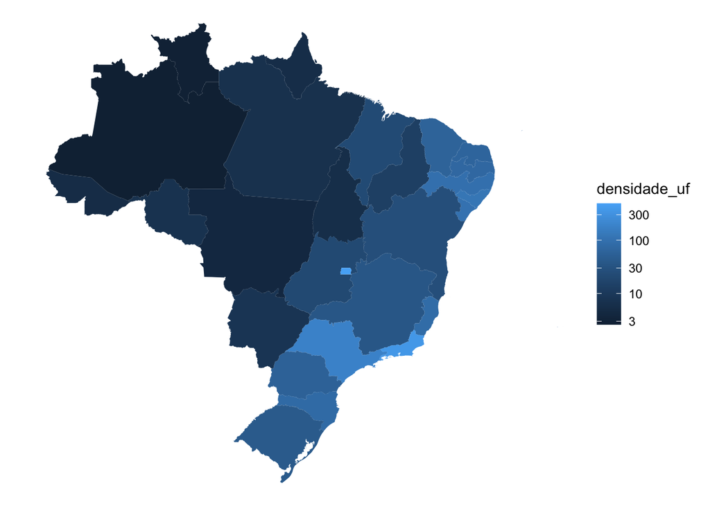

```r
uf_densidade <-
  uf |>
  left_join(densidade_uf, by = "uf")

ggplot() +
  geom_sf(data = uf_densidade, aes(fill = densidade_uf), colour = NA) +
  scale_fill_gradient(trans = "log10")
```

# 4 Mapas sobre o Rio Grande do Norte

## 4.1 Estado Inteiro

Não é necessário baixar os mapas de cada cidade brasileira quando eestivermos interessados em apenas um estado da nação. O argumento `code_muni` nos auxilia com isso, caso queiramos plotar o mapa da densidade populacional do Rio Grande do Norte:

```r
rn <- read_municipality(code_muni = "RN", year = 2020, showProgress = FALSE)
```

```
## Using year 2020
```

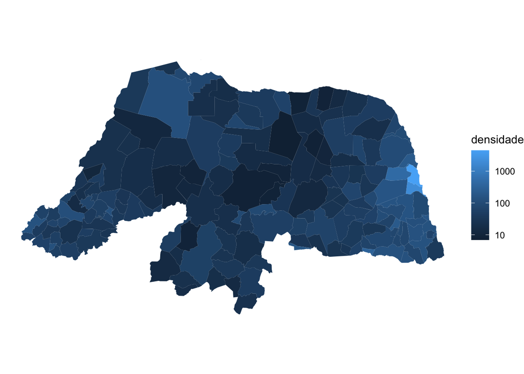

```r
rn <-
  rn |>
  rename(codigo_ibge = code_muni) |>
  left_join(brasil, by = "codigo_ibge")

ggplot() +
  geom_sf(data = rn, aes(fill = densidade), colour = NA) +
  scale_fill_gradient(trans = "log10")
```

## 4.2 Natal

Também é possível plotar dados apenas de uma cidade em particular. Para Natal, a função `read_neighborhood` plota cada bairro da cidade separadamente:

```r
natal <- read_neighborhood(year = 2010, showProgress = FALSE)
```

```
## Using year 2010
```

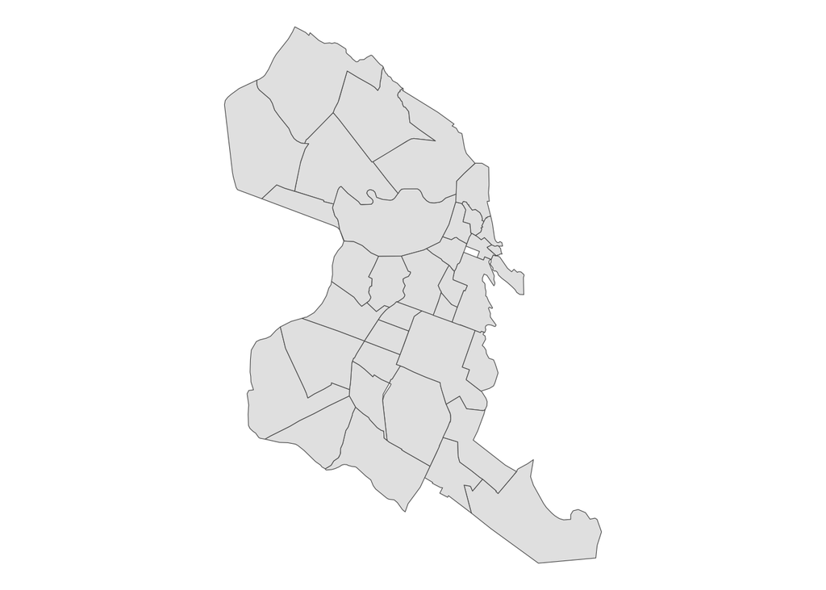

```r
natal <-
  natal |>
  filter(name_muni == "Natal")

ggplot() +
  geom_sf(data = natal)
```

# 5 Exercícios

1. Utilize o arquivo `dados/pib_per_capita.csv` para criar um mapa do Brasil com as UFs coloridas de acordo com o PIB per capita.
2. Crie um mapa com as cidades do Nordeste coloridas de acordo com a densidade populacional. É necessário criar 9 objetos com os mapas de cada estado individualmente e juntá-los em seguida.
3. Plote um mapa do Brasil com a localização dos patrimônios mundiais naturais localizados no país.